# Basic statistical inference

## Packages for this section

```r
library(tidyverse)
```

## Inference for means (from STAB57)

Three kinds of inference for means of normally-distributed data:

- **One-sample $t$**: a single sample from a population, estimate that population’s mean
- **Two-sample $t$**: one sample from each of 2 populations, estimate difference in population means
- **Matched pairs $t$**: two paired measurements on same (or matched) individuals, estimate population mean difference

Two forms of inference for a population parameter:

- **Confidence interval**: “what is the population parameter?”
- **Hypothesis test**: “could the population parameter be equal to this value?”

## Examples:

- Blue jays attendances (one-sample)
- Kids learning to read (two-sample)
- Pain relief (matched pairs)

## Confidence interval

- You have a sample from some population
- Imagine repeated sampling from that population
- Procedure that gives an interval containing the true parameter in 95% (or 90% or 99%) of all possible samples

## Hypothesis test

- Null hypothesis gives value for population parameter
- Alternative hypothesis says how you are trying to prove the null hypothesis wrong (not equal, greater, less).
- Test statistic measures “distance” between data and null hypothesis
- P-value gives probability of observing test statistic *as extreme or more extreme*, **if the null hypothesis is true**.
- Reject null hypothesis if P-value small enough (eg smaller than 0.05).

## Why 0.05? This man.

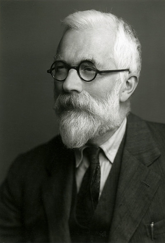

- analysis of variance
- Fisher information
- Linear discriminant analysis
- Fisher’s $z$-transformation
- Fisher-Yates shuffle
- Behrens-Fisher problem

Sir Ronald A. Fisher, 1890–1962.

## Why 0.05? (2)

- From The Arrangement of Field Experiments (1926):

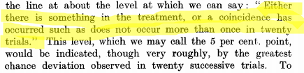

- and

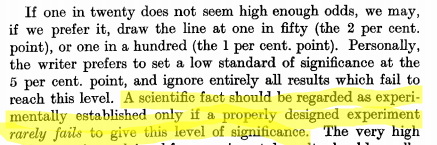

## $\alpha$ and errors

- Hypothesis test ends with decision:
  - reject null hypothesis
  - do not reject null hypothesis.
- but decision may be wrong:

|  | Decision |  |
| --- | --- | --- |
| **Truth** | **Do not reject** | **reject null** |
| **Null true** | Correct | Type I error |
| **Null false** | Type II error | Correct |

- Either type of error is bad, but for now focus on controlling Type I error: write $\alpha$ = P(type I error), and devise test so that $\alpha$ small, typically 0.05.
- That is, **if null hypothesis true**, have only small chance to reject it (which would be a mistake).
- Worry about type II errors later (when we consider power of test).

## One sample: the Blue Jays attendances

- The Toronto Blue Jays’ average home attendance in part of 2015 season was 25,070 (up to May 27 2015, from baseball-reference.com).
- Does that mean the attendance at every game was exactly 25,070? Certainly not. Actual attendance depends on many things, eg.:
  - how well the Jays are playing
  - the opposition
  - day of week
  - weather
  - random chance

## Reading the attendances

…as a `.csv` file:

```r
my_url <- "http://ritsokiguess.site/datafiles/jays15-home.csv"
jays <- read_csv(my_url)
jays
```

| row | game | date | box | team | venue | opp | result | runs | Oppruns | innings | wl | position | gb | winner | loser | save | game time | Daynight | attendance | streak |
| --- | --- | --- | --- | --- | --- | --- | --- | --- | --- | --- | --- | --- | --- | --- | --- | --- | --- | --- | --- | --- |
| 82 | 7 | Monday, Apr 13 | boxscore | TOR | NA | TBR | L | 1 | 2 | NA | 4-3 | 2 | 1 | Odorizzi | Dickey | Boxberger | 02:30:00 | N | 48414 | - |
| 83 | 8 | Tuesday, Apr 14 | boxscore | TOR | NA | TBR | L | 2 | 3 | NA | 4-4 | 3 | 2 | Geltz | Castro | Jepsen | 03:06:00 | N | 17264 | -- |
| 84 | 9 | Wednesday, Apr 15 | boxscore | TOR | NA | TBR | W | 12 | 7 | NA | 5-4 | 2 | 1 | Buehrle | Ramirez | NA | 03:02:00 | N | 15086 | + |
| 85 | 10 | Thursday, Apr 16 | boxscore | TOR | NA | TBR | L | 2 | 4 | NA | 5-5 | 4 | 1.5 | Archer | Sanchez | Boxberger | 03:00:00 | N | 14433 | - |
| 86 | 11 | Friday, Apr 17 | boxscore | TOR | NA | ATL | L | 7 | 8 | NA | 5-6 | 4 | 2.5 | Martin | Cecil | Grilli | 03:09:00 | N | 21397 | -- |
| 87 | 12 | Saturday, Apr 18 | boxscore | TOR | NA | ATL | W-wo | 6 | 5 | 10 | 6-6 | 3 | 1.5 | Cecil | Marimon | NA | 02:41:00 | D | 34743 | + |
| 88 | 13 | Sunday, Apr 19 | boxscore | TOR | NA | ATL | L | 2 | 5 | NA | 6-7 | 4 | 1.5 | Miller | Norris | Grilli | 02:41:00 | D | 44794 | - |
| 89 | 14 | Tuesday, Apr 21 | boxscore | TOR | NA | BAL | W | 13 | 6 | NA | 7-7 | 2 | 2 | Buehrle | Norris | NA | 02:53:00 | N | 14184 | + |
| 90 | 15 | Wednesday, Apr 22 | boxscore | TOR | NA | BAL | W | 4 | 2 | NA | 8-7 | 2 | 1 | Sanchez | Jimenez | Castro | 02:36:00 | N | 15606 | ++ |
| 91 | 16 | Thursday, Apr 23 | boxscore | TOR | NA | BAL | W | 7 | 6 | NA | 9-7 | 1 | Tied | Hutchison | Tillman | Castro | 02:36:00 | N | 18581 | +++ |

[output cut: 15 more lines]

## Another way

- This is a “big” data set: only 25 observations, but a lot of *variables*.
- To see the first few values in all the variables, can also use `glimpse`:

```r
glimpse(jays)
```

```
Rows: 25
Columns: 21
$ row         <dbl> 82, 83, 84, 85, 86, 87, 88, 89, 90, 91, 92, 93, 94, 95, 96…
$ game        <dbl> 7, 8, 9, 10, 11, 12, 13, 14, 15, 16, 27, 28, 29, 30, 31, 3…
$ date        <chr> "Monday, Apr 13", "Tuesday, Apr 14", "Wednesday, Apr 15", …
$ box         <chr> "boxscore", "boxscore", "boxscore", "boxscore", "boxscore"…
$ team        <chr> "TOR", "TOR", "TOR", "TOR", "TOR", "TOR", "TOR", "TOR", "T…
$ venue       <lgl> NA, NA, NA, NA, NA, NA, NA, NA, NA, NA, NA, NA, NA, NA, NA…
$ opp         <chr> "TBR", "TBR", "TBR", "TBR", "ATL", "ATL", "ATL", "BAL", "B…
$ result      <chr> "L", "L", "W", "L", "L", "W-wo", "L", "W", "W", "W", "W", …
$ runs        <dbl> 1, 2, 12, 2, 7, 6, 2, 13, 4, 7, 3, 3, 5, 7, 7, 3, 10, 2, 3…
$ Oppruns     <dbl> 2, 3, 7, 4, 8, 5, 5, 6, 2, 6, 1, 6, 1, 0, 1, 6, 6, 3, 4, 4…
$ innings     <dbl> NA, NA, NA, NA, NA, 10, NA, NA, NA, NA, NA, NA, NA, NA, NA…
$ wl          <chr> "4-3", "4-4", "5-4", "5-5", "5-6", "6-6", "6-7", "7-7", "8…
$ position    <dbl> 2, 3, 2, 4, 4, 3, 4, 2, 2, 1, 4, 5, 3, 3, 3, 3, 5, 5, 5, 5…
$ gb          <chr> "1", "2", "1", "1.5", "2.5", "1.5", "1.5", "2", "1", "Tied…
$ winner      <chr> "Odorizzi", "Geltz", "Buehrle", "Archer", "Martin", "Cecil…
$ loser       <chr> "Dickey", "Castro", "Ramirez", "Sanchez", "Cecil", "Marimo…
$ save        <chr> "Boxberger", "Jepsen", NA, "Boxberger", "Grilli", NA, "Gri…
$ `game time` <time> 02:30:00, 03:06:00, 03:02:00, 03:00:00, 03:09:00, 02:41:0…
$ Daynight    <chr> "N", "N", "N", "N", "N", "D", "D", "N", "N", "N", "N", "N"…
$ attendance  <dbl> 48414, 17264, 15086, 14433, 21397, 34743, 44794, 14184, 15…
$ streak      <chr> "-", "--", "+", "-", "--", "+", "-", "+", "++", "+++", "+"…
```

## Attendance histogram

```r
ggplot(jays, aes(x = attendance)) + geom_histogram(bins = 6)
```

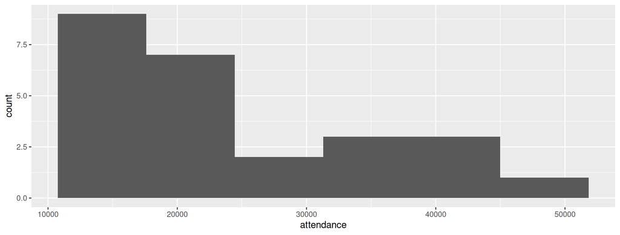

## Comments

- Attendances have substantial variability, ranging from just over 10,000 to around 50,000.
- Distribution somewhat skewed to right (but no outliers).
- These are a sample of “all possible games” (or maybe “all possible games played in April and May”). What can we say about mean attendance in all possible games based on this evidence?

## CI for mean attendance

- `t.test` function does CI and test. Look at CI first:

```r
t.test(jays$attendance)
```

```
    One Sample t-test

data:  jays$attendance
t = 11.389, df = 24, p-value = 3.661e-11
alternative hypothesis: true mean is not equal to 0
95 percent confidence interval:
 20526.82 29613.50
sample estimates:
mean of x
 25070.16
```

- From 20,500 to 29,600.

## Or, 90% CI

- by including a value for conf.level:

```r
t.test(jays$attendance, conf.level = 0.90)
```

```
    One Sample t-test

data:  jays$attendance
t = 11.389, df = 24, p-value = 3.661e-11
alternative hypothesis: true mean is not equal to 0
90 percent confidence interval:
 21303.93 28836.39
sample estimates:
mean of x
 25070.16
```

- From 21,300 to 28,800. (Shorter, as it should be.)

## Comments

- Need to say “column attendance within data frame `jays`” using `$`.
- 95% CI from about 20,000 to about 30,000.
- Not estimating mean attendance well at all!
- Generally want confidence interval to be shorter, which happens if:
  - SD smaller
  - sample size bigger
  - confidence level smaller
- Last one is a cheat, really, since reducing confidence level increases chance that interval won’t contain pop. mean at all!

## Another way to access data frame columns

```r
with(jays, t.test(attendance))
```

```
    One Sample t-test

data:  attendance
t = 11.389, df = 24, p-value = 3.661e-11
alternative hypothesis: true mean is not equal to 0
95 percent confidence interval:
 20526.82 29613.50
sample estimates:
mean of x
 25070.16
```

## Hypothesis testing for Blue Jays attendances

- Previous year’s mean attendance was 29,327, so test to see whether the mean is different from that in any way (two-sided test):

```r
t.test(jays$attendance, mu = 29327)
```

```
    One Sample t-test

data:  jays$attendance
t = -1.9338, df = 24, p-value = 0.06502
alternative hypothesis: true mean is not equal to 29327
95 percent confidence interval:
 20526.82 29613.50
sample estimates:
mean of x
 25070.16
```

- See test statistic $-1.93$, P-value 0.065.
- Do not reject null at $\alpha=0.05$: no evidence that mean attendance has changed.

## Another example: learning to read

- You devised new method for teaching children to read.
- Guess it will be more effective than current methods.
- To support this guess, collect data.
- Want to generalize to “all children in Canada”.
- So take random sample of all children in Canada.
- Or, argue that sample you actually have is “typical” of all children in Canada.
- Randomization (1): whether or not a child in sample or not has nothing to do with anything else about that child.
- Randomization (2): randomly choose whether each child gets new reading method (t) or standard one (c).

## Reading in data

- File at http://ritsokiguess.site/datafiles/drp.txt.
- Proper reading-in function is `read_delim` (check file to see)
- Read in thus:

```r
my_url <- "http://ritsokiguess.site/datafiles/drp.txt"
kids <- read_delim(my_url," ")
```

## The data (some)

```r
kids
```

| group | score |
| --- | --- |
| t | 24 |
| t | 61 |
| t | 59 |
| t | 46 |
| t | 43 |
| t | 44 |
| t | 52 |
| t | 43 |
| t | 58 |
| t | 67 |

[output cut: 34 more lines]

## Boxplots

```r
ggplot(kids, aes(x = group, y = score)) + geom_boxplot()
```

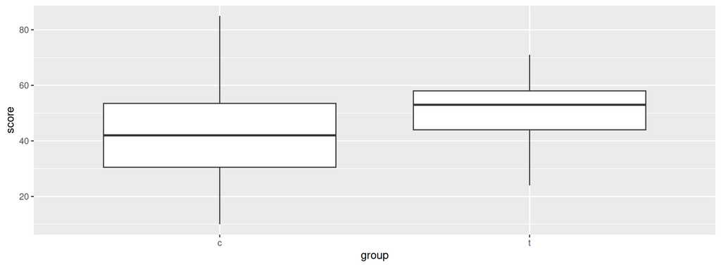

## Two kinds of two-sample t-test

- Do the two groups have same spread (SD, variance)?
  - If yes (shaky assumption here), can use pooled t-test.
  - If not, use Welch-Satterthwaite t-test (safe).
- Pooled test derived in STAB57 (easier to derive, but assumes equal variances).
- Welch-Satterthwaite does not assume equality of variances.
- Assess (approx) equality of spreads using boxplot.

## The (Welch-Satterthwaite) t-test

- `c` (control) before `t` (treatment) alphabetically, so proper alternative is “less”.
- R does Welch-Satterthwaite test by default
- Answer to “does the new reading program really help?”
- (in a moment) how to get R to do pooled test?

## Welch-Satterthwaite

```r
t.test(score ~ group, data = kids, alternative = "less")
```

```
    Welch Two Sample t-test

data:  score by group
t = -2.3109, df = 37.855, p-value = 0.01319
alternative hypothesis: true difference in means between group c and group t is less than 0
95 percent confidence interval:
      -Inf -2.691293
sample estimates:
mean in group c mean in group t
       41.52174        51.47619
```

## The pooled t-test

```r
t.test(score ~ group, data = kids,
       alternative = "less", var.equal = TRUE)
```

```
    Two Sample t-test

data:  score by group
t = -2.2666, df = 42, p-value = 0.01431
alternative hypothesis: true difference in means between group c and group t is less than 0
95 percent confidence interval:
      -Inf -2.567497
sample estimates:
mean in group c mean in group t
       41.52174        51.47619
```

## Two-sided test; CI

- To do 2-sided test, leave out `alternative`:

```r
t.test(score ~ group, data = kids)
```

```
    Welch Two Sample t-test

data:  score by group
t = -2.3109, df = 37.855, p-value = 0.02638
alternative hypothesis: true difference in means between group c and group t is not equal to 0
95 percent confidence interval:
 -18.67588  -1.23302
sample estimates:
mean in group c mean in group t
       41.52174        51.47619
```

## Comments:

- P-values for pooled and Welch-Satterthwaite tests very similar (even though the pooled test seemed inferior): 0.013 vs. 0.014.
- Two-sided test also gives CI: new reading program increases average scores by somewhere between about 1 and 19 points.
- Confidence intervals inherently two-sided, so do 2-sided test to get them.

## Matched pairs data

- Data are comparison of 2 drugs for effectiveness at reducing pain.
  - 12 subjects (cases) were arthritis sufferers
  - Response is #hours of pain relief from each drug.
- In reading example, each child tried only one reading method.
- But here, each subject tried out both drugs, giving us two measurements.
  - Possible because, if you wait long enough, one drug has no influence over effect of other.
  - Advantage: focused comparison of drugs. Compare one drug with another on same person, removes a lot of variability due to differences between people.
  - Matched pairs, requires different analysis.
- Design: randomly choose 6 of 12 subjects to get drug A first, other 6 get drug B first.

## Paired t test: reading the data

Values aligned in columns:

```r
my_url <- "http://ritsokiguess.site/datafiles/analgesic.txt"
pain <- read_table(my_url)
```

## The data

```r
pain
```

| subject | druga | drugb |
| --- | --- | --- |
| 1 | 2.0 | 3.5 |
| 2 | 3.6 | 5.7 |
| 3 | 2.6 | 2.9 |
| 4 | 2.6 | 2.4 |
| 5 | 7.3 | 9.9 |
| 6 | 3.4 | 3.3 |
| 7 | 14.9 | 16.7 |
| 8 | 6.6 | 6.0 |
| 9 | 2.3 | 3.8 |
| 10 | 2.0 | 4.0 |

[output cut: 2 more lines]

## Paired *t*-test

```r
with(pain, t.test(druga, drugb, paired = T))
```

```
    Paired t-test

data:  druga and drugb
t = -2.1677, df = 11, p-value = 0.05299
alternative hypothesis: true mean difference is not equal to 0
95 percent confidence interval:
 -4.29941513  0.03274847
sample estimates:
mean difference
      -2.133333
```

- P-value is 0.053.
- Not quite evidence of difference between drugs.

## t-testing the differences

- Likewise, you can calculate the differences yourself and do a 1-sample t-test on them.
- First calculate a column of differences:

```r
(pain %>% mutate(diff=druga-drugb) -> pain)
```

| subject | druga | drugb | diff |
| --- | --- | --- | --- |
| 1 | 2.0 | 3.5 | -1.5 |
| 2 | 3.6 | 5.7 | -2.1 |
| 3 | 2.6 | 2.9 | -0.3 |
| 4 | 2.6 | 2.4 | 0.2 |
| 5 | 7.3 | 9.9 | -2.6 |
| 6 | 3.4 | 3.3 | 0.1 |
| 7 | 14.9 | 16.7 | -1.8 |
| 8 | 6.6 | 6.0 | 0.6 |
| 9 | 2.3 | 3.8 | -1.5 |
| 10 | 2.0 | 4.0 | -2.0 |

[output cut: 2 more lines]

## t-test on the differences

- then throw them into t.test, testing that the mean is zero, with same result as before:

```r
with(pain, t.test(diff, mu=0))
```

```
    One Sample t-test

data:  diff
t = -2.1677, df = 11, p-value = 0.05299
alternative hypothesis: true mean is not equal to 0
95 percent confidence interval:
 -4.29941513  0.03274847
sample estimates:
mean of x
-2.133333
```